# WHO Measles Outbreak Investigation

Research Question

What socioeconomic factors have an effect on Measles infection rate? Are these socioeconomic factors correlated with vaccine coverage rate?

Measles Cases per Million (M) Averages Across Time & Region Heatmap

[interactive chart not shown]

Global Measles Cases in 2024

[interactive chart not shown]

**Average MCV1 Coverage**

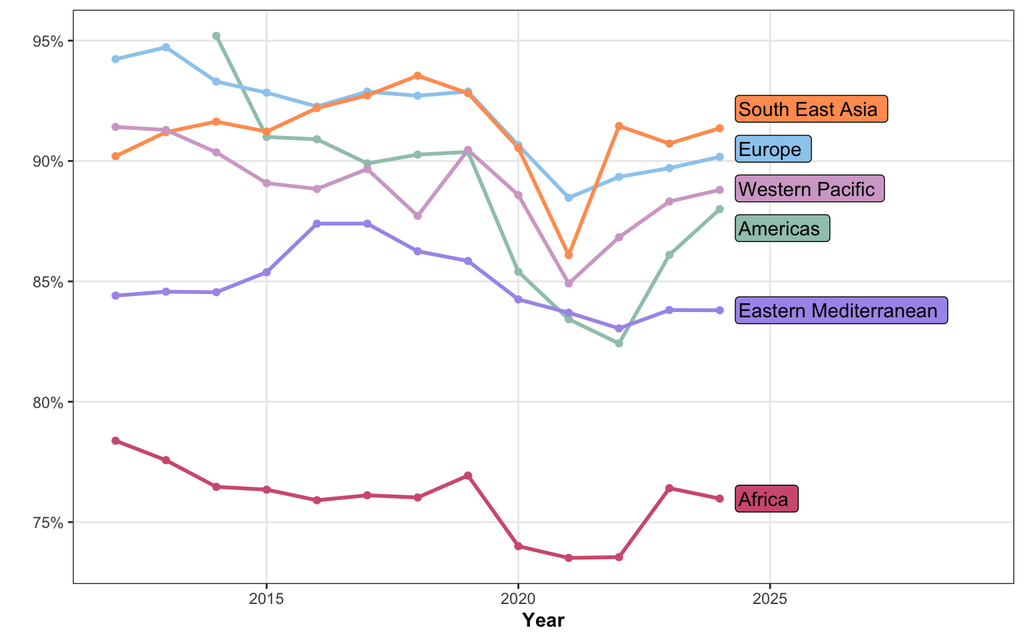

**Demographics Correlations**

[output not shown]

**MCV1 vs. GDP Plot**

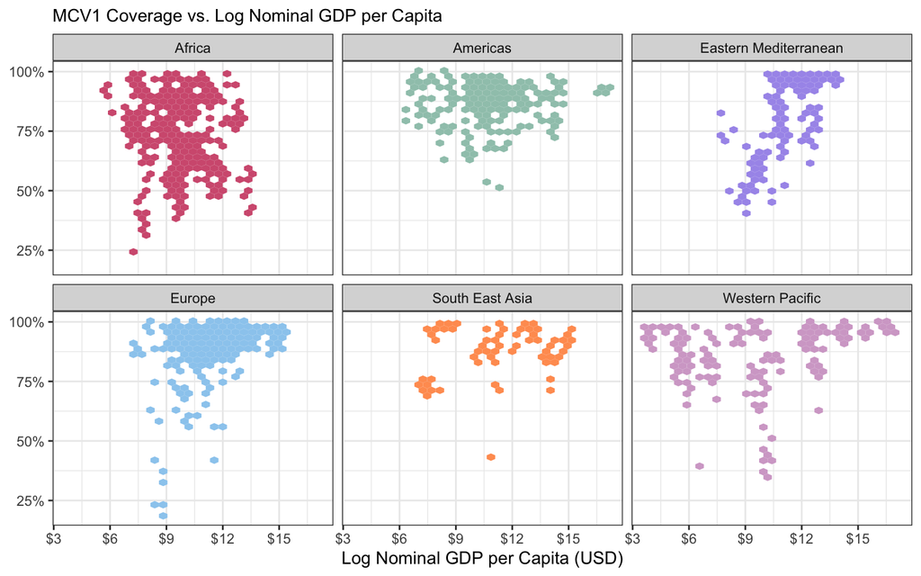

Why Romania?

Based on our Global Annual Measles heatmap, we observed that the Western Pacific region had the highest measles cases per million from 2014-2016. However, most recent data from 2024 shows that Europe now leads in measles cases per million. Focusing on Europe, we found that Romania is an informative case: its population of 19.07 million is roughly representative of the region, and it reported the largest total measles cases and the third highest average cases in Europe 2024, making it an interest for further analysis.

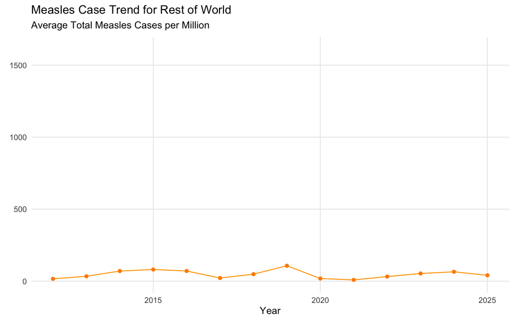

Socioeconomic Data

Select Data

Findings